# hw4_answer – Eesha Jagdhane

Eesha Jagdhane // Portfolio

- Home
- Blogs & Insights

Get in touch

Assignment 4 — Marketing Analytics

MaxDiff & Multinomial Logit

Which MSBA classes would students actually choose — if they had to?

Eesha Jagdhane · May 25, 2026

← Back to Blogs & Insights

## Introduction

Ask someone to *rate* ten MBA classes on a 1–10 scale and you get polite noise. Ask them to pick the **one they want** and the **one they’d skip** from a lineup of four — now you’re measuring something real. That’s **MaxDiff** (best–worst scaling): repeated forced choices instead of pretend precision.

Our “products” are the ten core MSBA classes at Rady. Each survey screen shows four; every pick is a miniature conjoint experiment. I take the class survey data and estimate preferences three ways — from a quick scoreboard to a full choice model — and see whether the story holds up:

1. **Counts** — how often a class is picked best vs. worst when it appears on screen
2. **Multinomial logit (MLE)** — a proper model of *how* people choose best and worst, with standard errors
3. **Bayesian MNL** — the same model, but with a prior and MCMC so uncertainty is honest about *shares*, not just coefficients

The methods mostly agree on who’s on top and who’s at the bottom. The fun is in the middle — and in the **interactive charts** (hover, zoom, toggle) plus a few **animations** where the statistics literally move.

## The Data

**Show Python code**

```python
import base64
import io
import json
import struct
from pathlib import Path
import uuid

import matplotlib.animation as manim
import matplotlib.pyplot as plt
import numpy as np
import pandas as pd
import plotly.graph_objects as go
import plotly.io as pio
from IPython.display import HTML, Markdown, display
from scipy import optimize
from scipy.special import logsumexp
from scipy.stats import norm

DATA_DIR = Path(".")
if not (DATA_DIR / "maxdiff_design_and_choices.csv").exists():
    DATA_DIR = Path("blogs/HW4")

ACCENT = "#2e2825"
BG = "#f0ece4"
PANEL = "#e8e3da"
GRID = "#c9c2b6"
HIGHLIGHT = "#7a3b35"

SHORT_LAB = [
    "403 AI/Math", "464 SQL", "451 MFO", "452 Large Data", "453 Biz Analytics",
    "444 Consulting", "455 Customer", "454 Capstone", "495 Mkt Analytics", "457 BI Systems",
]


def markdown_table(headers: list[str], rows: list[list[str]]) -> str:
    lines = [
        "| " + " | ".join(headers) + " |",
        "| " + " | ".join(["---"] * len(headers)) + " |",
    ]
    lines.extend("| " + " | ".join(r) + " |" for r in rows)
    return "\n".join(lines)


pio.templates.default = "simple_white"


def style_axes(ax):
    ax.set_facecolor(PANEL)
    ax.figure.set_facecolor(BG)
    ax.grid(True, axis="x", color=GRID, linewidth=0.7)
    for spine in ("top", "right"):
        ax.spines[spine].set_visible(False)
    ax.tick_params(colors="#8a8278")
    ax.xaxis.label.set_color(ACCENT)
    ax.yaxis.label.set_color(ACCENT)
    ax.title.set_color(ACCENT)


def _plain_json(obj):
    """Recursively convert numpy/plotly types to JSON-safe plain Python (no bdata)."""
    if isinstance(obj, dict):
        if "bdata" in obj and "dtype" in obj:
            return _decode_bdata(obj)
        return {k: _plain_json(v) for k, v in obj.items()}
    if isinstance(obj, (list, tuple)):
        return [_plain_json(v) for v in obj]
    if isinstance(obj, np.ndarray):
        return obj.tolist()
    if isinstance(obj, (np.integer, np.floating, np.bool_)):
        return obj.item()
    return obj


def _decode_bdata(obj: dict) -> list:
    raw = base64.b64decode(obj["bdata"])
    dtype = obj["dtype"]
    if dtype == "f8":
        return list(struct.unpack(f"<{len(raw) // 8}d", raw))
    if dtype == "f4":
        return list(struct.unpack(f"<{len(raw) // 4}f", raw))
    if dtype == "i2":
        return list(struct.unpack(f"<{len(raw) // 2}h", raw))
    if dtype == "i4":
        return list(struct.unpack(f"<{len(raw) // 4}i", raw))
    return list(raw)


def embed_plotly(fig: go.Figure, div_id: str, height: int) -> str:
    """Embed Plotly via JSON (avoids binary bdata + script timing issues on GitHub Pages)."""
    fig.update_layout(
        height=height,
        paper_bgcolor=BG,
        plot_bgcolor=PANEL,
        font=dict(color=ACCENT, family="DM Sans, sans-serif"),
    )
    fig.update_xaxes(gridcolor=GRID, zerolinecolor=GRID)
    fig.update_yaxes(gridcolor=GRID, zerolinecolor=GRID)
    raw = fig.to_dict()
    layout = _plain_json(raw.get("layout", {}))
    layout.pop("template", None)
    payload = json.dumps(
        {
            "data": _plain_json(raw.get("data", [])),
            "layout": layout,
            "config": {"displayModeBar": True, "responsive": False},
        }
    )
    return f"""<div id="{div_id}" class="plotly-graph-div" style="width:100%;height:{height}px;"></div>
<script>
(function() {{
  function decodeBdata(obj) {{
    if (Array.isArray(obj)) return obj.map(decodeBdata);
    if (obj && typeof obj === "object") {{
      if (obj.bdata && obj.dtype) {{
        var bin = atob(obj.bdata);
        var buf = new ArrayBuffer(bin.length);
        var view = new Uint8Array(buf);
        for (var i = 0; i < bin.length; i++) view[i] = bin.charCodeAt(i);
        if (obj.dtype === "f8") return Array.from(new Float64Array(buf));
        if (obj.dtype === "f4") return Array.from(new Float32Array(buf));
        if (obj.dtype === "i2") return Array.from(new Int16Array(buf));
        if (obj.dtype === "i4") return Array.from(new Int32Array(buf));
      }}
      var out = {{}};
      for (var k in obj) out[k] = decodeBdata(obj[k]);
      return out;
    }}
    return obj;
  }}
  var spec = decodeBdata({payload});
  function drawPlot() {{
    if (typeof Plotly === "undefined") {{
      setTimeout(drawPlot, 50);
      return;
    }}
    var el = document.getElementById("{div_id}");
    if (!el || el.dataset.plotlyDrawn === "1") return;
    Plotly.newPlot(el, spec.data, spec.layout, spec.config).then(function() {{
      el.dataset.plotlyDrawn = "1";
      if (typeof Plotly.Plots !== "undefined") Plotly.Plots.resize(el);
    }}).catch(function(err) {{
      console.error("Plotly failed ({div_id}):", err);
      el.innerHTML = "<p style='color:#7a3b35;font-size:0.9rem'>Chart could not load — try a hard refresh.</p>";
    }});
  }}
  if (document.readyState === "loading") {{
    document.addEventListener("DOMContentLoaded", drawPlot);
  }} else {{
    drawPlot();
  }}
}})();
</script>"""


def show_plotly(fig: go.Figure, height=None, caption=None) -> None:
    """Embed Plotly in Quarto HTML (Plotly.js loaded once via mathjax.html)."""
    plot_h = int(height if height is not None else (fig.layout.height or 500))
    div_id = "plot-" + uuid.uuid4().hex[:10]
    html = embed_plotly(fig, div_id, plot_h)
    if caption:
        html += f'<p class="chart-caption"><em>{caption}</em></p>'
    display(HTML(html))


def _fig_to_b64(fig: plt.Figure) -> str:
    buf = io.BytesIO()
    fig.savefig(buf, format="png", dpi=140, bbox_inches="tight", facecolor=BG, edgecolor="none")
    plt.close(fig)
    return base64.b64encode(buf.getvalue()).decode("ascii")


def show_three_way_comparison(cmp: pd.DataFrame) -> None:
    """Render comparison table + matplotlib bar charts (tabs) — reliable on GitHub Pages."""
    d = cmp.sort_values("mle_rank").copy()
    d["counts_pct"] = d["counts_score"] * 100
    d["mle_pct"] = d["mle_share"] * 100
    d["bayes_pct"] = d["bayes_share"] * 100

    show = d[
        [
            "Item",
            "short",
            "counts_score",
            "counts_rank",
            "mle_share",
            "mle_rank",
            "bayes_share",
            "bayes_rank",
        ]
    ].copy()
    show.columns = [
        "Item",
        "Class",
        "Counts score",
        "Counts rank",
        "MLE share",
        "MLE rank",
        "Bayes share",
        "Bayes rank",
    ]
    for col in ("Counts rank", "MLE rank", "Bayes rank"):
        show[col] = show[col].astype(int)
    table_html = show.to_html(index=False, border=0, classes="caption-top", float_format="%.3f")

    panels = [
        ("counts", "Counts", "counts_pct", "Counts score (percentage points)", "#8a8278", False),
        ("mle", "MLE", "mle_pct", "MLE share (%)", "#7a3b35", True),
        ("bayes", "Bayesian", "bayes_pct", "Bayesian share (%)", "#2e2825", False),
    ]
    images: dict[str, str] = {}
    for key, _label, col, xlab, color, _default in panels:
        plot_d = d.sort_values(col, ascending=True)
        fig_h = max(3.8, 0.38 * len(plot_d))
        fig, ax = plt.subplots(figsize=(7.2, fig_h))
        y = np.arange(len(plot_d))
        ax.barh(y, plot_d[col].to_numpy(), color=color, height=0.72, edgecolor="none")
        ax.set_yticks(y)
        ax.set_yticklabels(plot_d["short"])
        ax.set_xlabel(xlab)
        ax.set_title("Same classes, three metrics — pick your lens", fontsize=11, color=ACCENT, pad=10)
        style_axes(ax)
        if key == "counts":
            ax.axvline(0, color="#8a8278", linewidth=1, linestyle="--", alpha=0.85)
        images[key] = _fig_to_b64(fig)

    tabs = "".join(
        f'<button type="button" class="cmp-tab{" active" if default else ""}" '
        f'data-cmp-panel="{key}" onclick="hw4ShowCmpPanel(\'{key}\')">{label}</button>'
        for key, label, _col, _xlab, _color, default in panels
    )
    imgs = "".join(
        f'<img id="cmp-panel-{key}" class="cmp-panel-img{" active" if default else ""}" '
        f'src="data:…" alt="{label} ranking chart">'
        for key, label, _col, _xlab, _color, default in panels
    )
    chart_html = f"""<div class="comparison-chart-wrap">
<div class="comparison-tabs">{tabs}</div>
{imgs}
</div>
<script>
function hw4ShowCmpPanel(key) {{
  document.querySelectorAll(".cmp-panel-img").forEach(function(el) {{
    var on = el.id === "cmp-panel-" + key;
    el.classList.toggle("active", on);
    el.style.display = on ? "block" : "none";
  }});
  document.querySelectorAll(".cmp-tab").forEach(function(btn) {{
    btn.classList.toggle("active", btn.dataset.cmpPanel === key);
  }});
}}
</script>"""
    display(HTML(f'<div class="comparison-block">{table_html}{chart_html}</div>'))


def show_animation(anim: manim.FuncAnimation, mode: str = "once") -> None:
    display(HTML(anim.to_jshtml(default_mode=mode)))


def hbar_with_ci(
    df: pd.DataFrame,
    y_col: str,
    x_col: str,
    lo_col: str,
    hi_col: str,
    title: str,
    x_label: str,
    color: str = HIGHLIGHT,
) -> None:
    d = df.sort_values(x_col)
    x = d[x_col].to_numpy()
    fig = go.Figure(
        go.Bar(
            y=d[y_col],
            x=x,
            orientation="h",
            marker_color=color,
            error_x=dict(
                type="data",
                symmetric=False,
                array=np.maximum(0, d[hi_col].to_numpy() - x),
                arrayminus=np.maximum(0, x - d[lo_col].to_numpy()),
                color=ACCENT,
                thickness=1.5,
            ),
            hovertemplate=f"<b>%{{y}}</b><br>{x_label}: %{{x:.3f}}<extra></extra>",
        )
    )
    fig.add_vline(x=0, line_dash="dash", line_color="#8a8278", line_width=1)
    fig.update_layout(title=title, xaxis_title=x_label, yaxis=dict(categoryorder="total ascending"))
    show_plotly(fig)

raw = pd.read_csv(DATA_DIR / "maxdiff_design_and_choices.csv")
raw = raw.rename(columns={"Record ID": "record_id"})

labels = pd.read_csv(DATA_DIR / "maxdiff_item_labels.csv", usecols=["Item #", "Item"])
labels = labels.rename(columns={"Item #": "item", "Item": "label"})

# Standard 4-item MaxDiff tasks (exclude placeholder item 11 on 2-item screens)
raw10 = raw.loc[raw["Item"] <= 10].copy()
task_n = raw10.groupby(["record_id", "Task"]).size().reset_index(name="n")
raw4 = raw10.merge(task_n.loc[task_n["n"] == 4], on=["record_id", "Task"])

n_resp = raw4["record_id"].nunique()
t_per = raw4.groupby("record_id")["Task"].nunique().mean()
j_per = raw4["Position"].nunique()
n_items = raw4["Item"].nunique()
```

| Quantity | Value |
| --- | --- |
| Respondents ($N$) | 85 |
| MaxDiff tasks per respondent ($T$) | 8.0 (tasks 1–8) |
| Items per task ($J$) | 4 |
| Classes in the study | 10 |

Think of the CSV as a stack of tiny choice menus: one row per class slot on each screen. After keeping only the **ten real MSBA classes** and **four-class screens**, the table above summarizes the study.

One wrinkle: the export lists 15 “tasks” per person, but **tasks 9–15** are odd two-item screens with a placeholder (item 11). They’re not standard MaxDiff. I use **tasks 1–8** — four classes, one best, one worst — which is what the MNL math in class assumes.

**Show Python code**

```python
sanity = (
    raw4.groupby(["record_id", "Task"])["Response"]
    .agg(
        n_best=lambda s: (s == 1).sum(),
        n_worst=lambda s: (s == -1).sum(),
        n_zero=lambda s: (s == 0).sum(),
    )
    .reset_index()
)
n_fail = (
    (sanity["n_best"] != 1)
    | (sanity["n_worst"] != 1)
    | (sanity["n_zero"] != 2)
).sum()
print(f"Sanity-check failures: {n_fail} (expect 0)")

exposure = (
    raw4.groupby("Item")
    .size()
    .reset_index(name="times_shown")
    .merge(labels, left_on="Item", right_on="item")
)
exposure["short"] = exposure["Item"].map(lambda i: SHORT_LAB[i - 1])

display(
    Markdown(
        "**Exposure counts (balanced design)**\n\n"
        + markdown_table(
            ["Item", "Class", "Times shown"],
            [
                [str(int(r.Item)), r.short, str(int(r.times_shown))]
                for r in exposure.sort_values("Item").itertuples()
            ],
        )
    )
)
```

```
Sanity-check failures: 0 (expect 0)
```

**Exposure counts (balanced design)**

| Item | Class | Times shown |
| --- | --- | --- |
| 1 | 403 AI/Math | 273 |
| 2 | 464 SQL | 274 |
| 3 | 451 MFO | 272 |
| 4 | 452 Large Data | 276 |
| 5 | 453 Biz Analytics | 270 |
| 6 | 444 Consulting | 267 |
| 7 | 455 Customer | 276 |
| 8 | 454 Capstone | 272 |
| 9 | 495 Mkt Analytics | 274 |
| 10 | 457 BI Systems | 266 |

Exposure is beautifully balanced — each class shows up about **270** times. No class was accidentally hidden from the debate.

## Counts Analysis

Start with the scoreboard even your advisor could read in ten seconds. For each class $j$, track how often it was picked **best** and **worst** when it appeared, then subtract:

$$\text{score}_j = \%\text{best}_j - \%\text{worst}_j.$$

A score near **+1** means “crowd favorite whenever it’s on the menu.” Near **-1** means “please get this off my schedule.” Near **0** means fight night — the class is loved and hated in equal measure.

**Show Python code**

```python
counts = (
    raw4.groupby("Item")
    .agg(
        shown=("Response", "size"),
        times_best=("Response", lambda s: (s == 1).sum()),
        times_worst=("Response", lambda s: (s == -1).sum()),
    )
    .reset_index()
)
counts["pct_best"] = counts["times_best"] / counts["shown"]
counts["pct_worst"] = counts["times_worst"] / counts["shown"]
counts["score"] = counts["pct_best"] - counts["pct_worst"]
counts = counts.merge(labels, left_on="Item", right_on="item")
counts["short"] = counts["Item"].map(lambda i: SHORT_LAB[i - 1])
counts = counts.sort_values("score", ascending=False)

display(
    Markdown(
        markdown_table(
            [
                "Item", "Class", "Shown", "Best", "Worst",
                "% best", "% worst", "Score",
            ],
            [
                [
                    str(int(r.Item)),
                    r.short,
                    str(int(r.shown)),
                    str(int(r.times_best)),
                    str(int(r.times_worst)),
                    f"{100 * r.pct_best:.1f}",
                    f"{100 * r.pct_worst:.1f}",
                    f"{r.score:.3f}",
                ]
                for r in counts.itertuples()
            ],
        )
    )
)
```

| Item | Class | Shown | Best | Worst | % best | % worst | Score |
| --- | --- | --- | --- | --- | --- | --- | --- |
| 9 | 495 Mkt Analytics | 274 | 147 | 12 | 53.6 | 4.4 | 0.493 |
| 5 | 453 Biz Analytics | 270 | 93 | 55 | 34.4 | 20.4 | 0.141 |
| 7 | 455 Customer | 276 | 104 | 71 | 37.7 | 25.7 | 0.120 |
| 4 | 452 Large Data | 276 | 77 | 60 | 27.9 | 21.7 | 0.062 |
| 8 | 454 Capstone | 272 | 72 | 69 | 26.5 | 25.4 | 0.011 |
| 2 | 464 SQL | 274 | 55 | 56 | 20.1 | 20.4 | -0.004 |
| 10 | 457 BI Systems | 266 | 23 | 55 | 8.6 | 20.7 | -0.120 |
| 1 | 403 AI/Math | 273 | 33 | 90 | 12.1 | 33.0 | -0.209 |
| 3 | 451 MFO | 272 | 43 | 101 | 15.8 | 37.1 | -0.213 |
| 6 | 444 Consulting | 267 | 33 | 111 | 12.4 | 41.6 | -0.292 |

**Show Python code**

```python
def bootstrap_counts(
    data: pd.DataFrame, B: int = 1000, seed: int = 495
) -> tuple[np.ndarray, pd.DataFrame]:
    """Return bootstrap draw matrix (B × 10) and CI table by Item."""
    rng = np.random.default_rng(seed)
    ids = data["record_id"].unique()
    items = np.arange(1, 11)
    mat = np.full((B, len(items)), np.nan)
    for b in range(B):
        samp = rng.choice(ids, size=len(ids), replace=True)
        d = data[data["record_id"].isin(samp)]
        sc = d.groupby("Item").agg(
            shown=("Response", "size"),
            best=("Response", lambda s: (s == 1).sum()),
            worst=("Response", lambda s: (s == -1).sum()),
        )
        sc["score"] = sc["best"] / sc["shown"] - sc["worst"] / sc["shown"]
        mat[b, :] = sc.reindex(items)["score"].to_numpy()
    ci = pd.DataFrame(
        {
            "Item": items,
            "ci_lo": np.quantile(mat, 0.025, axis=0),
            "ci_hi": np.quantile(mat, 0.975, axis=0),
        }
    )
    return mat, ci


boot_mat, boot_ci = bootstrap_counts(raw4)
counts = counts.merge(boot_ci, on="Item", how="left")

hbar_with_ci(
    counts,
    y_col="short",
    x_col="score",
    lo_col="ci_lo",
    hi_col="ci_hi",
    title="Class preferences: counts analysis",
    x_label="Counts score (% best − % worst)",
)
```

[interactive chart not shown]

Counts scores with 95% bootstrap CIs (resampling respondents, B = 1,000).

Hover on any bar for the score; zoom if you want detail on the middle of the pack. The animation below resamples students 1,000 times and rebuilds the bootstrap distribution for **MGTA 495** — watch the histogram settle and the 95% interval appear.

[figure not shown]

Once Loop Reflect

Bootstrap distribution of the MGTA 495 counts score (B = 1,000 resamples).

**MGTA 495 Marketing Analytics** is the runaway winner — best on **54%** of screens, worst on **4%**, for a score of **0.49**. **453** and **455** trail but still feel like “first-round picks.” At the bottom, **444 Consulting** is the class people love to hate (worst **42%** of the time). **464 SQL** is the Switzerland of the portfolio: nearly zero net score, which usually means the fancier models will argue over its rank.

## From MaxDiff Data to MNL Choices

Counts are honest; they’re also wasteful. They ignore every time you *didn’t* pick a class. The multinomial logit (MNL) turns each MaxDiff screen into **two** statistical choices:

1. **Best choice** from all $J=4$ items on the screen, with utility $\beta_j$ and probability $P(\text{best}=b) = \exp(\beta_b) / \sum_{j \in \text{shown}} \exp(\beta_j)$.
2. **Worst choice** from the three remaining items, with utilities **negated**: $P(\text{worst}=c \mid \text{best}=b) = \exp(-\beta_c) / \sum_{j \neq b} \exp(-\beta_j)$.

One catch: utilities are only defined up to a constant. I pin **$\beta_1 = 0$** (MGTA 403 as the reference class) and estimate the other nine — standard move, same as setting the outside option to zero in class.

**Show Python code**

```python
def build_tasks(df: pd.DataFrame) -> list[dict]:
    rows = []
    for _, g in df.groupby(["record_id", "Task"]):
        rows.append(
            {
                "items": g["Item"].astype(int).tolist(),
                "best": int(g.loc[g["Response"] == 1, "Item"].iloc[0]),
                "worst": int(g.loc[g["Response"] == -1, "Item"].iloc[0]),
            }
        )
    return rows


tasks = build_tasks(raw4)
print(f"MNL choice rows: {2 * len(tasks)} (2 per task)")


def prepare_task_arrays(task_rows: list[dict]) -> tuple[np.ndarray, np.ndarray, np.ndarray, np.ndarray]:
    """Precompute 0-based indices so each likelihood call avoids Python dict work."""
    n = len(task_rows)
    items = np.zeros((n, 4), dtype=np.int32)
    best = np.zeros(n, dtype=np.int32)
    worst = np.zeros(n, dtype=np.int32)
    rem = np.zeros((n, 3), dtype=np.int32)
    for i, row in enumerate(task_rows):
        it = np.asarray(row["items"], dtype=np.int32) - 1
        jb = row["best"] - 1
        items[i] = it
        best[i] = jb
        worst[i] = row["worst"] - 1
        rem[i] = it[it != jb]
    return items, best, worst, rem


TASK_ITEMS, TASK_BEST, TASK_WORST, TASK_REM = prepare_task_arrays(tasks)
pd.DataFrame(tasks).head()
```

```
MNL choice rows: 1360 (2 per task)
```

|  | items | best | worst |
| --- | --- | --- | --- |
| 0 | [5, 7, 4, 1] | 7 | 1 |
| 1 | [8, 3, 10, 9] | 10 | 8 |
| 2 | [3, 5, 2, 6] | 2 | 6 |
| 3 | [6, 4, 8, 7] | 7 | 6 |
| 4 | [2, 9, 7, 1] | 2 | 1 |

## MNL via Maximum Likelihood

Summing over all tasks, the log-likelihood is

$$\ell(\boldsymbol{\beta}) = \sum_{\text{tasks}} \Big[
\beta_{j^*_b} - \log \sum_{j \in \text{shown}} e^{\beta_j}
- \beta_{j^*_w} - \log \sum_{j \in \text{shown}\setminus\{j^*_b\}} e^{-\beta_j}
\Big].$$

I code the log-likelihood with **`logsumexp`** (so `exp` never explodes), then let `scipy.optimize.minimize` hunt for the peak. Below: an **interactive** log-likelihood slice (hover along the curve) and an **animation** that walks **β₉** toward the MLE while other coefficients stay fixed.

**Show Python code**

```python
def beta_full(b9: np.ndarray) -> np.ndarray:
    return np.concatenate([[0.0], np.asarray(b9, dtype=float)])


def log_likelihood(b9: np.ndarray) -> float:
    """Vectorized over all tasks (same math as the loop version)."""
    b = beta_full(b9)
    vb = b[TASK_ITEMS]
    best_part = b[TASK_BEST] - logsumexp(vb, axis=1)
    vw = -b[TASK_REM]
    worst_part = -b[TASK_WORST] - logsumexp(vw, axis=1)
    return (best_part + worst_part).sum()


mle_res = optimize.minimize(
    lambda x: -log_likelihood(x),
    np.zeros(9),
    method="BFGS",
)

b_hat = beta_full(mle_res.x)
se_free = np.sqrt(np.diag(mle_res.hess_inv))
se_full = np.concatenate([[0.0], se_free])
shares = np.exp(b_hat) / np.exp(b_hat).sum()

mle_tbl = pd.DataFrame({
    "Item": np.arange(1, 11),
    "beta": b_hat,
    "se": se_full,
    "share": shares,
})
mle_tbl = mle_tbl.merge(labels, left_on="Item", right_on="item")
mle_tbl["short"] = mle_tbl["Item"].map(lambda i: SHORT_LAB[i - 1])
mle_tbl = mle_tbl.sort_values("share", ascending=False)

display(
    Markdown(
        markdown_table(
            ["Item", "Class", "β̂", "SE", "Share"],
            [
                [
                    str(int(r.Item)),
                    r.short,
                    f"{r.beta:.3f}",
                    f"{r.se:.3f}",
                    f"{r.share:.3f}",
                ]
                for r in mle_tbl.itertuples()
            ],
        )
    )
)
```

| Item | Class | β̂ | SE | Share |
| --- | --- | --- | --- | --- |
| 9 | 495 Mkt Analytics | 1.630 | 0.115 | 0.284 |
| 5 | 453 Biz Analytics | 0.744 | 0.130 | 0.117 |
| 7 | 455 Customer | 0.656 | 0.120 | 0.107 |
| 4 | 452 Large Data | 0.555 | 0.115 | 0.097 |
| 8 | 454 Capstone | 0.443 | 0.116 | 0.087 |
| 2 | 464 SQL | 0.438 | 0.109 | 0.086 |
| 10 | 457 BI Systems | 0.236 | 0.116 | 0.070 |
| 1 | 403 AI/Math | 0.000 | 0.000 | 0.056 |
| 3 | 451 MFO | -0.067 | 0.115 | 0.052 |
| 6 | 444 Consulting | -0.239 | 0.126 | 0.044 |

[interactive chart not shown]

Interactive log-likelihood slice: vary β₉ (495) while other coefficients stay at the MLE.

[figure not shown]

Once Loop Reflect

Animated sweep: moving β₉ (495) toward the MLE while other coefficients stay fixed.

[interactive chart not shown]

MLE shares of preference — interactive; hover for share on a hypothetical all-class screen.

Every class keeps the **same rank** as the counts table — reassuring. The MNL just translates utilities into something marketers understand: **share of preference** if all ten classes appeared on one mega-screen. **495** grabs about **28%** of that imaginary demand; **444 Consulting** about **4%**.

## MNL via Bayesian Estimation

MLE gives a point. Bayes gives a *cloud*. The posterior is $\pi(\boldsymbol{\beta} \mid \mathbf{y}) \propto L(\boldsymbol{\beta})\,\pi(\boldsymbol{\beta})$ with a gentle prior $\boldsymbol{\beta} \sim N(\mathbf{0}, 10\mathbf{I})$ — wide enough to stay out of the way, tight enough to keep the sampler sane.

**Show Python code**

```python
def log_posterior(b9: np.ndarray) -> float:
    return log_likelihood(b9) + norm.logpdf(b9, loc=0, scale=np.sqrt(10)).sum()


def metropolis_hastings(
    beta0: np.ndarray,
    n_iter: int,
    step: float,
    seed: int = 495,
    label: str = "MCMC",
    progress_every: int = 2_000,
) -> tuple[np.ndarray, float]:
    rng = np.random.default_rng(seed)
    k = len(beta0)
    draws = np.empty((n_iter, k))
    beta = beta0.copy()
    lp = log_posterior(beta)
    accept = 0
    print(f"{label}: starting {n_iter:,} iterations...", flush=True)
    for t in range(n_iter):
        beta_star = beta + rng.normal(0, step, size=k)
        lp_star = log_posterior(beta_star)
        if np.log(rng.random()) < lp_star - lp:
            beta = beta_star
            lp = lp_star
            accept += 1
        draws[t] = beta
        if progress_every and (t + 1) % progress_every == 0:
            print(
                f"{label}: {t + 1:,} / {n_iter:,} — acceptance so far {accept / (t + 1):.3f}",
                flush=True,
            )
    return draws, accept / n_iter


# Tune step size toward 25–40% acceptance
step = 0.12
for trial_i in range(6):
    trial_draws, trial_acc = metropolis_hastings(
        mle_res.x, 3000, step, seed=495 + trial_i, label=f"Tuning trial {trial_i + 1}"
    )
    print(f"step = {step:.3f}, acceptance = {trial_acc:.3f}", flush=True)
    if 0.25 <= trial_acc <= 0.40:
        break
    step = step / 2 if trial_acc < 0.25 else step * 1.15

mh_draws, accept_rate = metropolis_hastings(
    mle_res.x, n_iter=20_000, step=step, seed=495, label="Main chain"
)
print(f"Final acceptance rate: {accept_rate:.3f}", flush=True)

burn = mh_draws.shape[0] // 4
post_draws = mh_draws[burn:]

beta_mean = beta_full(post_draws.mean(axis=0))
beta_ci = np.quantile(post_draws, [0.025, 0.975], axis=0)

b_post = np.column_stack([np.zeros(post_draws.shape[0]), post_draws])
b_post -= b_post.max(axis=1, keepdims=True)
exp_b = np.exp(b_post)
share_draws = exp_b / exp_b.sum(axis=1, keepdims=True)
share_mean = share_draws.mean(axis=0)
share_ci = np.quantile(share_draws, [0.025, 0.975], axis=0)

bayes_tbl = pd.DataFrame({
    "Item": np.arange(1, 11),
    "beta_mean": beta_mean,
    "beta_lo": np.concatenate([[0.0], beta_ci[0]]),
    "beta_hi": np.concatenate([[0.0], beta_ci[1]]),
    "share_mean": share_mean,
    "share_lo": share_ci[0],
    "share_hi": share_ci[1],
})
bayes_tbl = bayes_tbl.merge(labels, left_on="Item", right_on="item")
bayes_tbl["short"] = bayes_tbl["Item"].map(lambda i: SHORT_LAB[i - 1])
bayes_tbl = bayes_tbl.sort_values("share_mean", ascending=False)

display(
    Markdown(
        markdown_table(
            ["Item", "Class", "β mean", "β 95% CI", "Share mean"],
            [
                [
                    str(int(r.Item)),
                    r.short,
                    f"{r.beta_mean:.3f}",
                    f"[{r.beta_lo:.2f}, {r.beta_hi:.2f}]",
                    f"{r.share_mean:.3f}",
                ]
                for r in bayes_tbl.itertuples()
            ],
        )
    )
)
```

```
Tuning trial 1: starting 3,000 iterations...
Tuning trial 1: 2,000 / 3,000 — acceptance so far 0.126
step = 0.120, acceptance = 0.127
Tuning trial 2: starting 3,000 iterations...
Tuning trial 2: 2,000 / 3,000 — acceptance so far 0.419
step = 0.060, acceptance = 0.409
Tuning trial 3: starting 3,000 iterations...
Tuning trial 3: 2,000 / 3,000 — acceptance so far 0.368
step = 0.069, acceptance = 0.364
Main chain: starting 20,000 iterations...
Main chain: 2,000 / 20,000 — acceptance so far 0.349
Main chain: 4,000 / 20,000 — acceptance so far 0.363
Main chain: 6,000 / 20,000 — acceptance so far 0.361
Main chain: 8,000 / 20,000 — acceptance so far 0.363
Main chain: 10,000 / 20,000 — acceptance so far 0.359
Main chain: 12,000 / 20,000 — acceptance so far 0.360
Main chain: 14,000 / 20,000 — acceptance so far 0.356
Main chain: 16,000 / 20,000 — acceptance so far 0.357
Main chain: 18,000 / 20,000 — acceptance so far 0.360
Main chain: 20,000 / 20,000 — acceptance so far 0.359
Final acceptance rate: 0.359
```

| Item | Class | β mean | β 95% CI | Share mean |
| --- | --- | --- | --- | --- |
| 9 | 495 Mkt Analytics | 1.630 | [1.37, 1.89] | 0.284 |
| 5 | 453 Biz Analytics | 0.738 | [0.47, 1.03] | 0.117 |
| 7 | 455 Customer | 0.661 | [0.38, 0.96] | 0.108 |
| 4 | 452 Large Data | 0.552 | [0.26, 0.83] | 0.097 |
| 8 | 454 Capstone | 0.441 | [0.16, 0.73] | 0.087 |
| 2 | 464 SQL | 0.432 | [0.17, 0.71] | 0.086 |
| 10 | 457 BI Systems | 0.236 | [-0.02, 0.51] | 0.071 |
| 1 | 403 AI/Math | 0.000 | [0.00, 0.00] | 0.056 |
| 3 | 451 MFO | -0.061 | [-0.33, 0.24] | 0.052 |
| 6 | 444 Consulting | -0.235 | [-0.50, 0.06] | 0.044 |

[figure not shown]

Once Loop Reflect

MCMC trace for β₉ (495) building up after burn-in — look for the fuzzy caterpillar.

[interactive chart not shown]

Interactive MCMC traces — use the buttons below the chart to switch parameter (495, 453, 444).

[interactive chart not shown]

Bayesian posterior mean shares with 95% credible intervals (hover + zoom).

Posterior means hug the MLE (β₉ ≈ **1.63** either way). The real win is on **shares**: every MCMC draw gets pushed through the softmax, so the error bars on the bar chart are *credible intervals*, not approximations from a formula you hope is right.

## Comparing the Three Methods

Same ten classes, three lenses. The table is the scoreboard; the chart lets you flip between **Counts**, **MLE**, and **Bayesian** shares with one click.

| Item | Class | Counts score | Counts rank | MLE share | MLE rank | Bayes share | Bayes rank |
| --- | --- | --- | --- | --- | --- | --- | --- |
| 9 | 495 Mkt Analytics | 0.493 | 1 | 0.284 | 1 | 0.284 | 1 |
| 5 | 453 Biz Analytics | 0.141 | 2 | 0.117 | 2 | 0.117 | 2 |
| 7 | 455 Customer | 0.120 | 3 | 0.107 | 3 | 0.108 | 3 |
| 4 | 452 Large Data | 0.062 | 4 | 0.097 | 4 | 0.097 | 4 |
| 8 | 454 Capstone | 0.011 | 5 | 0.087 | 5 | 0.087 | 5 |
| 2 | 464 SQL | -0.004 | 6 | 0.086 | 6 | 0.086 | 6 |
| 10 | 457 BI Systems | -0.120 | 7 | 0.070 | 7 | 0.071 | 7 |
| 1 | 403 AI/Math | -0.209 | 8 | 0.056 | 8 | 0.056 | 8 |
| 3 | 451 MFO | -0.213 | 9 | 0.052 | 9 | 0.052 | 9 |
| 6 | 444 Consulting | -0.292 | 10 | 0.044 | 10 | 0.044 | 10 |

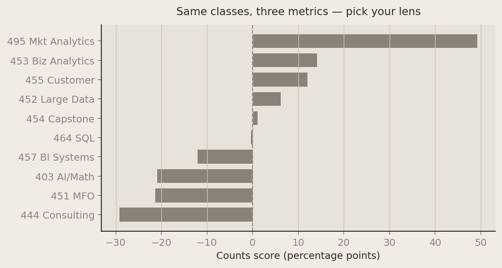

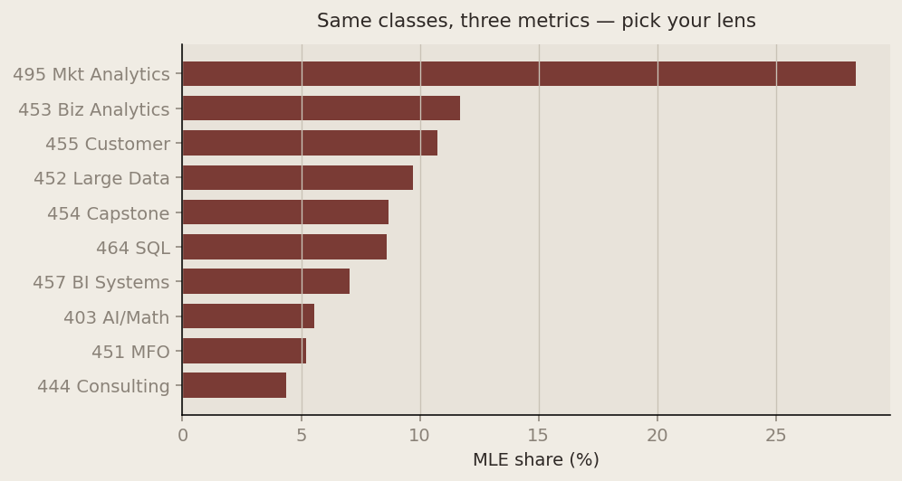

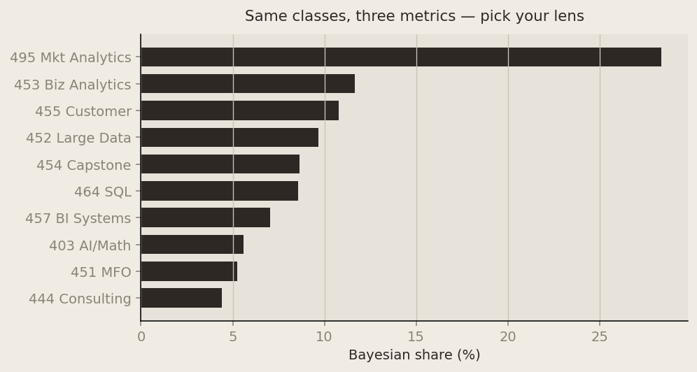

*Use the **Counts / MLE / Bayesian** buttons above the chart to switch views.*

When would I use each tool in real life?

- **Counts** — executive snapshot, no software drama.
- **MLE** — one number to put in a slide, with classical SEs.
- **Bayes** — “what if we add a new elective?” or any question where uncertainty on **shares** matters more than uncertainty on β.

## Discussion

If you’re choosing classes in this cohort, the market has spoken: **take 495**, load up on **453 / 455 / 452**, and treat **444** as the option of last resort unless you love client-facing grind. The gap isn’t subtle — roughly **28%** MNL share vs. **4%** for consulting.

Statistically, this homework is really about **three ways to listen to the same choices**. Counts are the podcast summary; MLE is the transcript with footnotes; Bayes is the transcript plus an honest “we’re not 100% sure” margin on the quotes that matter (market shares).

Caveats worth saying out loud: these are **MSBA students who took a survey**, not a random draw of all business students. Who’s already suffered through 403, who’s targeting marketing vs. finance, and which classes they’ve heard horror stories about — all unobserved. Tasks 9–15 in the raw file still look like a different survey mode (item 11 placeholder), so I stuck to the clean eight-task MaxDiff core.

If I had another afternoon: **hierarchical MNL** (who loves 495 *too much*?), covariates like concentration and work experience, and a story for those two-item screens. For now, the traces look like caterpillars, the likelihood has a clear peak, and Marketing Analytics won — which, in a Marketing Analytics class, feels fitting.

© 2026 Eesha Jagdhane Built with Quarto San Diego, CA